# Compte-Rendu Atelier Statistique

#### 4.Le gout

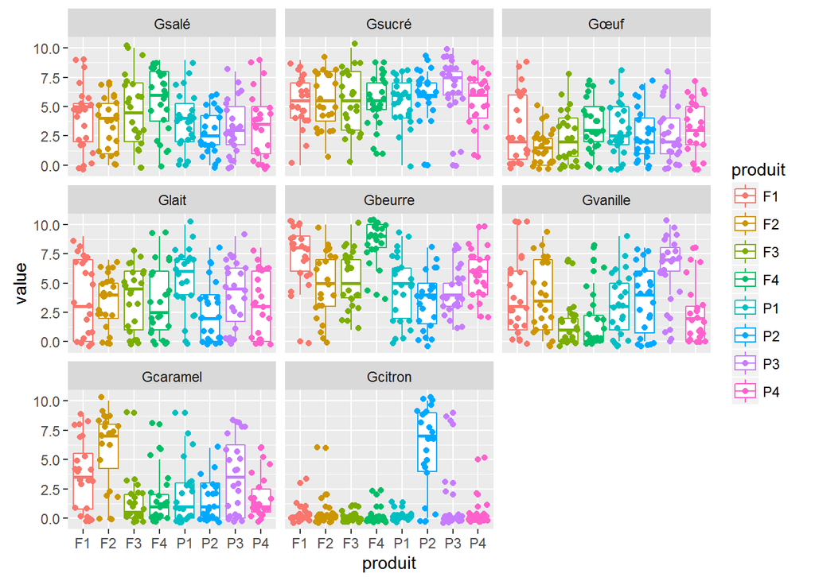

```r
d=ggplot(data.long4,aes(x=produit,y=value,colour=produit))+geom_boxplot()+geom_jitter()+facet_wrap(~variable)
plot(d)
```

**3.Résumé des données par variables**

```r
library(plyr)
Resume<-ddply(data, c("produit"), summarize, Moyenne=mean(Vcouleur, na.rm = T), "Ecart-type"=sd(Vcouleur, na.rm = T))
Resume<-format(Resume, digits=3, decimal.mark=",")
Resume
```

```
##   produit Moyenne Ecart-type
## 1      F1    6,08       1,89
## 2      F2    9,12       0,90
## 3      F3    3,00       2,27
## 4      F4    7,42       1,77
## 5      P1    3,54       1,59
## 6      P2    4,50       1,93
## 7      P3    5,92       1,50
## 8      P4    6,67       1,61
```

```r
Var_quant<-data[,-c(1,2,3)]
Var_quant=na.omit(Var_quant)
call=do.call(data.frame,list(mean=apply(Var_quant,2,mean),sd=apply(Var_quant,2,sd),median=apply(Var_quant,2,median),min=apply(Var_quant,2,min),n=apply(Var_quant,2,length)))
call
```

```
##                 mean       sd median min   n
## Vcouleur    5.745763 2.575628      6   0 177
## Vépaisseur  5.576271 2.668440      5   1 177
## Ouf        3.169492 2.689326      3   0 177
## Olait       3.728814 2.912535      4   0 177
## Obeurre     5.112994 3.052328      5   0 177
## Ovanille    3.802260 3.261413      4   0 177
## Ocaramel    2.892655 2.997120      2   0 177
## Ocitron     1.231638 2.612799      0   0 177
## Tdurcroq    5.536723 2.311055      5   0 177
## Tfriabilité 4.932203 2.825600      5   0 177
## Tgranusabl  5.802260 2.808347      6   0 177
## Tfarineux   5.474576 2.516012      6   0 177
## Tcraqcroust 5.480226 2.834628      6   0 177
## Tpâteux     5.000000 2.730301      5   0 177
## Tfondant    4.977401 2.748873      5   0 177
## Gsalé       3.807910 2.692022      4   0 177
## Gsucré      5.706215 2.234445      6   0 177
## Guf        2.745763 2.303110      2   0 177
## Glait       3.745763 2.834005      4   0 177
## Gbeurre     5.519774 2.818547      6   0 177
## Gvanille    3.378531 3.039175      3   0 177
## Gcaramel    2.666667 2.951630      1   0 177
## Gcitron     1.090395 2.550127      0   0 177
```

```r
Var_quali<-data[,1:3]
Var_quali
```

```
##     seance juge produit
## 1        1    1      F4
## 2        1    1      F2
## 3        1    1      P3
## 4        1    1      F3
## 5        1    1      P4
## 6        1    1      F1
## 7        1    1      P2
## 8        1    1      P1
## 9        1    2      F4
## 10       1    2      F2
## 11       1    2      P3
## 12       1    2      F3
## 13       1    2      P4
## 14       1    2      F1
```

[output cut: 178 more lines]

En utilisant le tableau moyen on obtient :

```r
library(survival)
library(doBy)
Tableau_moyen=summaryBy(.~produit,data,FUN = c(mean),na.rm=TRUE,keep.names = TRUE)
origine=c(rep("France",4),rep("Pakistan",4))
origine
```

```
## [1] "France"   "France"   "France"   "France"   "Pakistan" "Pakistan"
## [7] "Pakistan" "Pakistan"
```

```r
Tableau_moyen_originaire=cbind.data.frame(Tableau_moyen,origine,row.names=1)
Tableau_moyen_originaire
```

```
##    Vcouleur Vépaisseur     Ouf    Olait  Obeurre Ovanille Ocaramel
## F1 6.083333   3.125000 3.541667 3.541667 6.833333 4.958333 3.541667
## F2 9.125000   3.583333 1.541667 3.916667 5.041667 5.833333 5.541667
## F3 3.000000   8.875000 4.000000 3.583333 2.750000 1.083333 0.625000
## F4 7.416667   9.083333 3.875000 3.750000 8.583333 2.041667 1.666667
## P1 3.541667   3.333333 3.583333 5.666667 4.304348 3.666667 2.291667
## P2 4.500000   6.458333 2.000000 2.458333 3.125000 3.875000 2.208333
## P3 5.916667   4.208333 2.125000 3.416667 4.250000 6.416667 4.666667
## P4 6.666667   5.541667 5.083333 2.956522 5.583333 2.083333 2.500000
##       Ocitron Tdurcroq Tfriabilité Tgranusabl Tfarineux Tcraqcroust
## F1 0.25000000 5.083333    2.916667   5.173913  5.291667    7.916667
## F2 0.45833333 4.458333    3.625000   4.708333  5.958333    7.208333
## F3 0.16666667 4.416667    5.916667   7.000000  5.708333    2.791667
## F4 0.79166667 7.458333    7.458333   8.458333  5.250000    4.708333
## P1 0.08333333 6.333333    2.041667   3.916667  4.750000    6.916667
## P2 6.12500000 5.708333    7.541667   6.260870  5.583333    4.958333
## P3 1.04166667 6.416667    2.958333   5.208333  4.291667    6.875000
## P4 0.58333333 4.500000    6.708333   5.869565  6.833333    2.625000
##     Tpâteux Tfondant    Gsalé   Gsucré     Guf    Glait  Gbeurre Gvanille
## F1 5.791667 5.291667 4.000000 5.458333 3.000000 3.708333 7.375000 3.913043
## F2 5.958333 5.291667 3.583333 5.583333 1.583333 3.434783 4.833333 3.916667
## F3 4.416667 6.695652 4.541667 5.416667 2.416667 3.750000 5.250000 1.541667
## F4 5.000000 5.250000 5.458333 5.583333 3.375000 3.333333 8.458333 1.708333
## P1 4.250000 3.416667 3.750000 5.375000 3.000000 5.291667 4.583333 3.208333
## P2 5.250000 5.375000 2.791667 6.041667 2.583333 2.583333 3.434783 3.583333
## P3 3.250000 3.043478 3.166667 6.833333 2.625000 4.125000 4.260870 6.416667
## P4 5.958333 6.043478 3.458333 5.458333 3.250000 3.250000 5.791667 2.304348
##    Gcaramel   Gcitron  origine
## F1 3.625000 0.2916667   France
## F2 5.958333 0.4583333   France
## F3 1.250000 0.1666667   France
## F4 1.500000 0.2083333   France
## P1 1.958333 0.1250000 Pakistan
## P2 1.458333 6.0416667 Pakistan
## P3 3.625000 0.9166667 Pakistan
## P4 1.739130 0.3333333 Pakistan
```

### III-Analyse multivariée :

```r
library(FactoMineR)
dim(Tableau_moyen_originaire)
```

```
## [1]  8 24
```

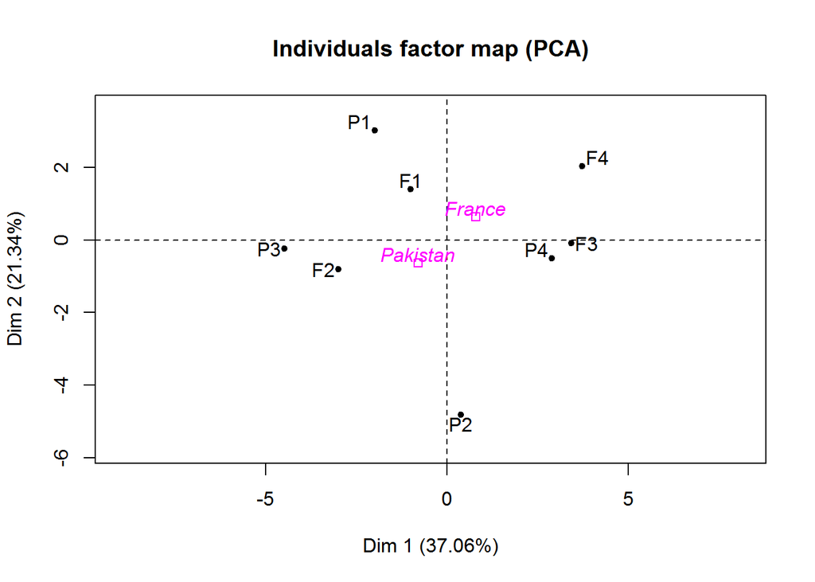

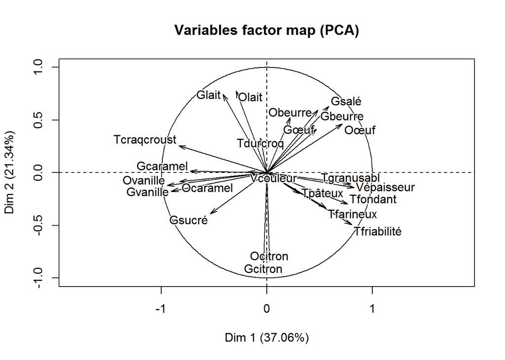

```r
res.pca=PCA(Tableau_moyen_originaire,scale.unit=T, ncp=2,quali.sup=24, graph=T)
```

D’après cette analyse en composantes principales on peut tirer les résultats suivants: P3 est le produit le plus sucré puisqu’il est caractèrisé par un goût caramel , goût vanille et Ocaramel appréciables .De même pour le produit F2 Ensuite le produit F4 est caractérisé par un goût salé , goût beurre et goût Ooeuf de valeur . Puis le produit F3 et P4 se privilégient par leur bonne patte: Tpâteux,Tfarineux et Tfondant acceptables.

```r
res.pca
```

```
## **Results for the Principal Component Analysis (PCA)**
## The analysis was performed on 8 individuals, described by 24 variables
## *The results are available in the following objects:
##
##    name
## 1  "$eig"
## 2  "$var"
## 3  "$var$coord"
## 4  "$var$cor"
## 5  "$var$cos2"
## 6  "$var$contrib"
## 7  "$ind"
## 8  "$ind$coord"
## 9  "$ind$cos2"
## 10 "$ind$contrib"
```

[output cut: 27 more lines]

```r
res.pca$eig
```

```
##        eigenvalue percentage of variance cumulative percentage of variance
## comp 1  8.5236786              37.059472                          37.05947
## comp 2  4.9084429              21.341056                          58.40053
## comp 3  3.9063247              16.984020                          75.38455
## comp 4  2.8800368              12.521899                          87.90645
## comp 5  1.3164671               5.723770                          93.63022
## comp 6  0.9905992               4.306953                          97.93717
## comp 7  0.4744508               2.062830                         100.00000
```

```r
res.pca $var
```

```
## $coord
##                   Dim.1        Dim.2
## Vcouleur    -0.17617766  0.007090838
## Vépaisseur   0.82700358 -0.142347054
## Ouf         0.71616001  0.464934651
## Olait       -0.29171690  0.777877100
## Obeurre      0.22256688  0.524768475
## Ovanille    -0.94355463 -0.120144736
## Ocaramel    -0.82556059 -0.083251947
## Ocitron      0.02562556 -0.840886086
## Tdurcroq    -0.05908155  0.329039285
## Tfriabilité  0.80371788 -0.495541971
## Tgranusabl   0.79346367 -0.106375048
## Tfarineux    0.55922211 -0.332475771
## Tcraqcroust -0.83566360  0.256477518
## Tpâteux      0.31077122 -0.197280305
## Tfondant     0.76651056 -0.299475435
## Gsalé        0.58716757  0.631643561
## Gsucré      -0.53618456 -0.390712219
## Guf         0.47155357  0.414102140
## Glait       -0.41717664  0.746263107
## Gbeurre      0.48590260  0.596328735
## Gvanille    -0.90572995 -0.175444232
## Gcaramel    -0.72691489  0.014408889
## Gcitron     -0.03086982 -0.852262006
##
## $cor
##                   Dim.1        Dim.2
## Vcouleur    -0.17617766  0.007090838
## Vépaisseur   0.82700358 -0.142347054
## Ouf         0.71616001  0.464934651
## Olait       -0.29171690  0.777877100
## Obeurre      0.22256688  0.524768475
## Ovanille    -0.94355463 -0.120144736
## Ocaramel    -0.82556059 -0.083251947
## Ocitron      0.02562556 -0.840886086
## Tdurcroq    -0.05908155  0.329039285
## Tfriabilité  0.80371788 -0.495541971
## Tgranusabl   0.79346367 -0.106375048
## Tfarineux    0.55922211 -0.332475771
```

[output cut: 48 more lines]

```
## Tdurcroq     0.040952146  2.205727043
## Tfriabilité  7.578446486  5.002846166
## Tgranusabl   7.386301383  0.230534431
## Tfarineux    3.668948369  2.252040846
## Tcraqcroust  8.192866948  1.340154488
## Tpâteux      1.133064209  0.792909686
## Tfondant     6.893014973  1.827168794
## Gsalé        4.044799994  8.128312781
## Gsucré       3.372885011  3.110070601
## Guf         2.608765293  3.493584166
## Glait        2.041798605 11.345932730
## Gbeurre      2.769946446  7.244822247
## Gvanille     9.624327541  0.627096609
## Gcaramel     6.199263040  0.004229775
## Gcitron      0.011179986 14.797982748
```

```r
res.pca$ind
```

```
## $coord
##         Dim.1       Dim.2
## F1 -0.9983325  1.40481717
## F2 -2.9907584 -0.80382813
## F3  3.4335526 -0.09134044
## F4  3.7327707  2.02744837
## P1 -1.9787389  3.01309043
## P2  0.3865534 -4.81021841
## P3 -4.4806292 -0.23158337
## P4  2.8955822 -0.50838561
##
## $cos2
##         Dim.1        Dim.2
## F1 0.10237877 0.2027211819
## F2 0.35236079 0.0254537236
## F3 0.53552590 0.0003789826
## F4 0.47172877 0.1391647837
## P1 0.16777902 0.3890317037
## P2 0.00539858 0.8359688978
## P3 0.68746448 0.0018364833
## P4 0.49001938 0.0151052508
##
## $contrib
##         Dim.1       Dim.2
## F1  1.4616162  5.02580792
## F2 13.1173346  1.64548027
## F3 17.2890191  0.02124675
## F4 20.4336319 10.46805224
## P1  5.7419569 23.12014778
## P2  0.2191301 58.92449470
## P3 29.4415688  0.13657808
## P4 12.2957424  0.65819226
##
## $dist
##       F1       F2       F3       F4       P1       P2       P3       P4
## 3.120112 5.038341 4.691951 5.434820 4.830807 5.261017 5.403982 4.136464
```

```r
res.pca$svd
```

```
## $vs
## [1] 2.9195340 2.2155006 1.9764424 1.6970671 1.1473740 0.9952885 0.6888039
##
## $U
##            [,1]       [,2]
## [1,] -0.3419493  0.6340857
## [2,] -1.0243958 -0.3628201
## [3,]  1.1760619 -0.0412279
## [4,]  1.2785502  0.9151198
## [5,] -0.6777585  1.3600043
## [6,]  0.1324024 -2.1711655
## [7,] -1.5347070 -0.1045287
## [8,]  0.9917960 -0.2294676
##
## $V
```

[output cut: 24 more lines]

```r
res.pca$quali.sup
```

```
## $coord
##               Dim.1      Dim.2
## France    0.7943081  0.6342742
## Pakistan -0.7943081 -0.6342742
##
## $cos2
##              Dim.1     Dim.2
## France   0.2328841 0.1484965
## Pakistan 0.2328841 0.1484965
##
## $v.test
##               Dim.1      Dim.2
## France    0.7198209  0.7574504
## Pakistan -0.7198209 -0.7574504
##
## $dist
##   France Pakistan
## 1.645959 1.645959
##
## $eta2
##              Dim.1     Dim.2
## origine 0.07402031 0.0819616
```

```r
res.pca$call
```

```
## $row.w
## [1] 0.125 0.125 0.125 0.125 0.125 0.125 0.125 0.125
##
## $col.w
##  [1] 1 1 1 1 1 1 1 1 1 1 1 1 1 1 1 1 1 1 1 1 1 1 1
##
## $scale.unit
## [1] TRUE
##
## $ncp
## [1] 2
##
## $centre
##  [1] 5.781250 5.526042 3.218750 3.661232 5.058877 3.744792 2.880208
##  [8] 1.187500 5.546875 4.895833 5.824502 5.458333 5.500000 4.984375
## [15] 5.050951 3.843750 5.718750 2.729167 3.684556 5.498415 3.324049
## [22] 2.639266 1.067708
##
## $ecart.type
##  [1] 1.9085824 2.2589461 1.1318752 0.8745465 1.8076306 1.7937775 1.5088623
##  [8] 1.8905604 1.0504706 2.1013802 1.3322870 0.7204840 1.9097475 0.9006502
## [15] 1.1538794 0.7833306 0.4647982 0.5335937 0.7389958 1.5612575 1.4650182
## [22] 1.5352546 1.8945666
##
## $X
##    Vcouleur Vépaisseur     Ouf    Olait  Obeurre Ovanille Ocaramel
## F1 6.083333   3.125000 3.541667 3.541667 6.833333 4.958333 3.541667
## F2 9.125000   3.583333 1.541667 3.916667 5.041667 5.833333 5.541667
## F3 3.000000   8.875000 4.000000 3.583333 2.750000 1.083333 0.625000
## F4 7.416667   9.083333 3.875000 3.750000 8.583333 2.041667 1.666667
## P1 3.541667   3.333333 3.583333 5.666667 4.304348 3.666667 2.291667
## P2 4.500000   6.458333 2.000000 2.458333 3.125000 3.875000 2.208333
## P3 5.916667   4.208333 2.125000 3.416667 4.250000 6.416667 4.666667
## P4 6.666667   5.541667 5.083333 2.956522 5.583333 2.083333 2.500000
##       Ocitron Tdurcroq Tfriabilité Tgranusabl Tfarineux Tcraqcroust
## F1 0.25000000 5.083333    2.916667   5.173913  5.291667    7.916667
## F2 0.45833333 4.458333    3.625000   4.708333  5.958333    7.208333
## F3 0.16666667 4.416667    5.916667   7.000000  5.708333    2.791667
## F4 0.79166667 7.458333    7.458333   8.458333  5.250000    4.708333
## P1 0.08333333 6.333333    2.041667   3.916667  4.750000    6.916667
```

[output cut: 48 more lines]

```
##          Vcouleur Vépaisseur     Ouf    Olait  Obeurre Ovanille Ocaramel
## France    6.40625   6.166667 3.239583 3.697917 5.802083 3.479167 2.843750
## Pakistan  5.15625   4.885417 3.197917 3.624547 4.315670 4.010417 2.916667
##            Ocitron Tdurcroq Tfriabilité Tgranusabl Tfarineux Tcraqcroust
## France   0.4166667 5.354167    4.979167   6.335145  5.552083     5.65625
## Pakistan 1.9583333 5.739583    4.812500   5.313859  5.364583     5.34375
##           Tpâteux Tfondant    Gsalé   Gsucré     Guf    Glait  Gbeurre
## France   5.291667 5.632246 4.395833 5.510417 2.593750 3.556612 6.479167
## Pakistan 4.677083 4.469656 3.291667 5.927083 2.864583 3.812500 4.517663
##          Gvanille Gcaramel  Gcitron
## France   2.769928 3.083333 0.281250
## Pakistan 3.878170 2.195199 1.854167
##
## $quali.sup$numero
## [1] 24
```

```r
res.pca$var$coord
```

```
##                   Dim.1        Dim.2
## Vcouleur    -0.17617766  0.007090838
## Vépaisseur   0.82700358 -0.142347054
## Ouf         0.71616001  0.464934651
## Olait       -0.29171690  0.777877100
## Obeurre      0.22256688  0.524768475
## Ovanille    -0.94355463 -0.120144736
## Ocaramel    -0.82556059 -0.083251947
## Ocitron      0.02562556 -0.840886086
## Tdurcroq    -0.05908155  0.329039285
## Tfriabilité  0.80371788 -0.495541971
## Tgranusabl   0.79346367 -0.106375048
## Tfarineux    0.55922211 -0.332475771
## Tcraqcroust -0.83566360  0.256477518
## Tpâteux      0.31077122 -0.197280305
## Tfondant     0.76651056 -0.299475435
## Gsalé        0.58716757  0.631643561
## Gsucré      -0.53618456 -0.390712219
## Guf         0.47155357  0.414102140
## Glait       -0.41717664  0.746263107
## Gbeurre      0.48590260  0.596328735
## Gvanille    -0.90572995 -0.175444232
## Gcaramel    -0.72691489  0.014408889
## Gcitron     -0.03086982 -0.852262006
```

```r
res.pca$var$cos2
```

```
##                    Dim.1        Dim.2
## Vcouleur    0.0310385692 5.027998e-05
## Vépaisseur  0.6839349280 2.026268e-02
## Ouf        0.5128851641 2.161642e-01
## Olait       0.0850987524 6.050928e-01
## Obeurre     0.0495360147 2.753820e-01
## Ovanille    0.8902953351 1.443476e-02
## Ocaramel    0.6815502941 6.930887e-03
## Ocitron     0.0006566696 7.070894e-01
## Tdurcroq    0.0034906293 1.082669e-01
## Tfriabilité 0.6459624229 2.455618e-01
## Tgranusabl  0.6295845918 1.131565e-02
## Tfarineux   0.3127293678 1.105401e-01
## Tcraqcroust 0.6983336485 6.578072e-02
## Tpâteux     0.0965787517 3.891952e-02
## Tfondant    0.5875384436 8.968554e-02
## Gsalé       0.3447657524 3.989736e-01
## Gsucré      0.2874938785 1.526560e-01
## Guf        0.2223627695 1.714806e-01
## Glait       0.1740363512 5.569086e-01
## Gbeurre     0.2361013330 3.556080e-01
## Gvanille    0.8203467490 3.078068e-02
## Gcaramel    0.5284052584 2.076161e-04
## Gcitron     0.0009529461 7.263505e-01
```

```r
names(res.pca)
```

```
## [1] "eig"       "var"       "ind"       "svd"       "quali.sup" "call"
```

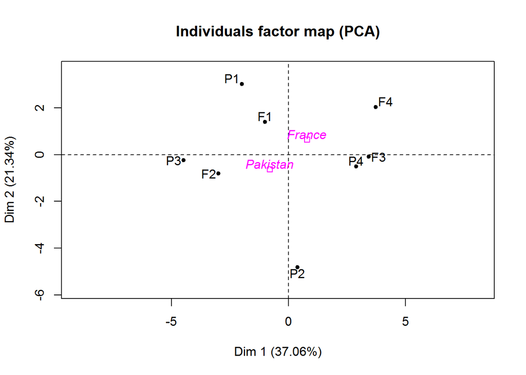

```r
plot(res.pca,choix = "ind" ,axes = 1:2)
```

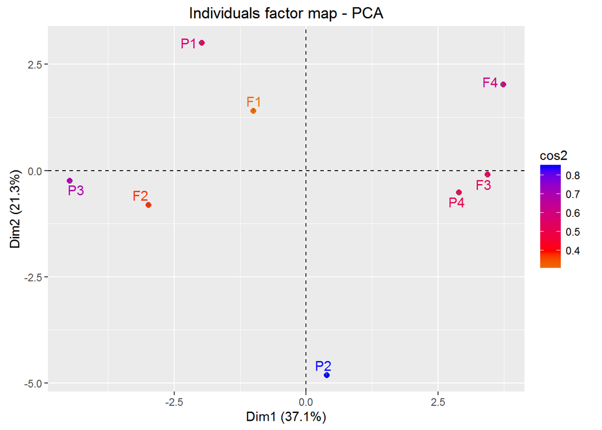

```r
library(ggplot2)
library(grid)
library(factoextra)
fviz_pca_ind(res.pca,geom=c("point","text"),col.ind="cos2")+scale_color_gradient2(low='green',mid='red',high='blue',midpoint=0.4)
```

```r
library(googleVis)
```

```r
line=gvisLineChart(Tableau_moyen_originaire,xvar='origine',yvar=c("Vcouleur","Gcitron"))
plot(line)
```

```
## starting httpd help server ...
```

```
##  done
```

[Line] (http://127.0.0.1:26473/custom/googleVis/LineChartID183051cf133e.html)

```r
bubble=gvisBubbleChart(Tableau_moyen,idvar ='produit',xvar = 'Gcitron',yvar = 'Vcouleur')
plot(bubble)
```

[Bubble] (http://127.0.0.1:26473/custom/googleVis/BubbleChartID1830c7f1d42.html)

```r
Bar<-gvisBarChart(Tableau_moyen, yvar=c("Vcouleur","Gcitron"))
plot(Bar)
```

[Bar] (http://127.0.0.1:26473/custom/googleVis/BarChartID18305110296.html)

```r
library(plotly)
p<-plot_ly(data=Tableau_moyen_originaire,x=Vcouleur,color=origine,type="box")
p
```

[interactive chart not shown]

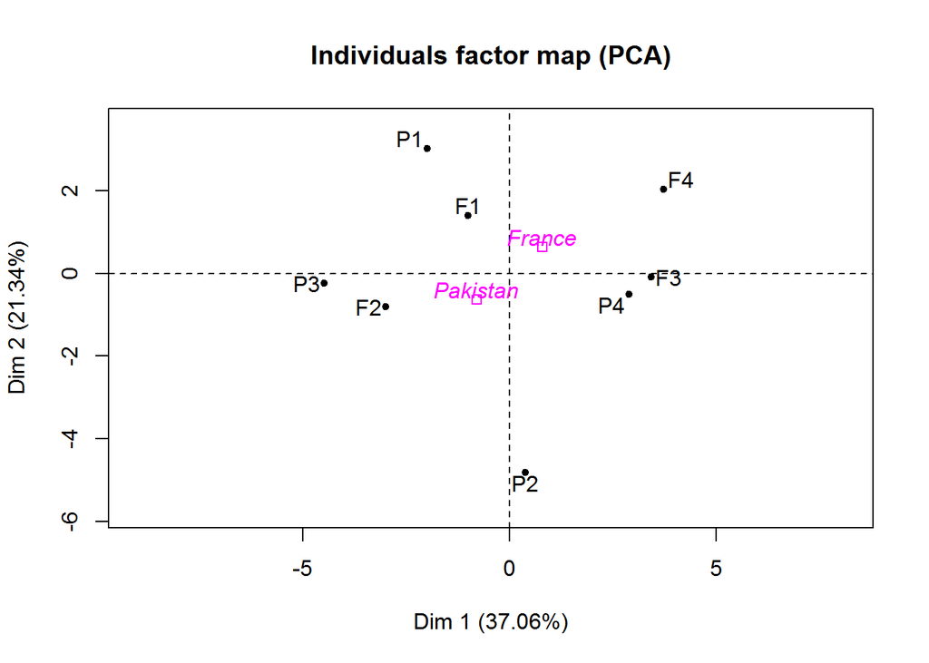

```r
plot(res.pca,choix = "ind" ,axes = 1:2)
```

```r
library(ggplot2)
library(factoextra)
library(googleVis)
library(doBy)
library(survival)
library(googleVis)
```

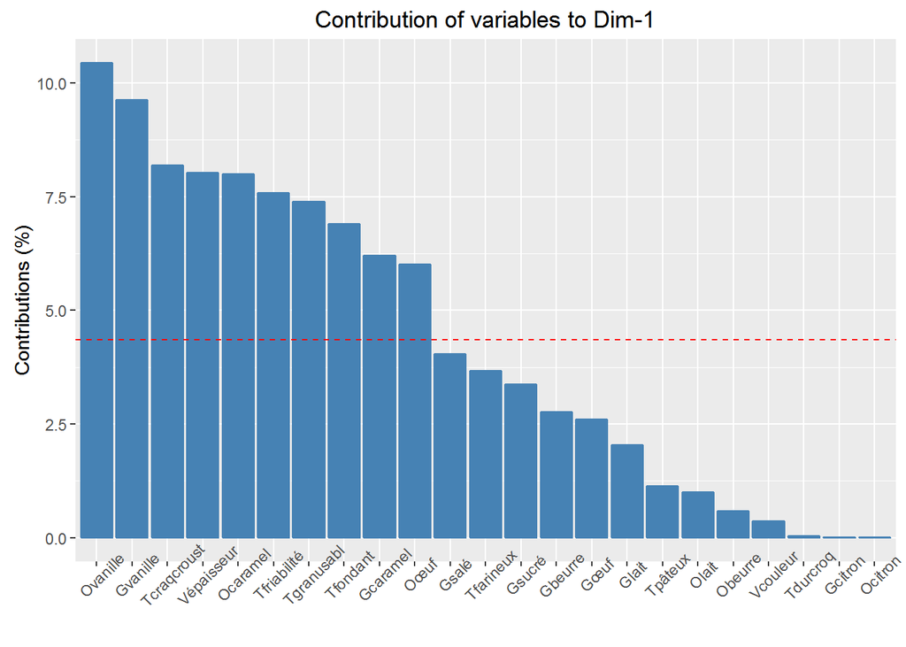

```r
fviz_contrib(res.pca , choice = "var", axes = 1)
```

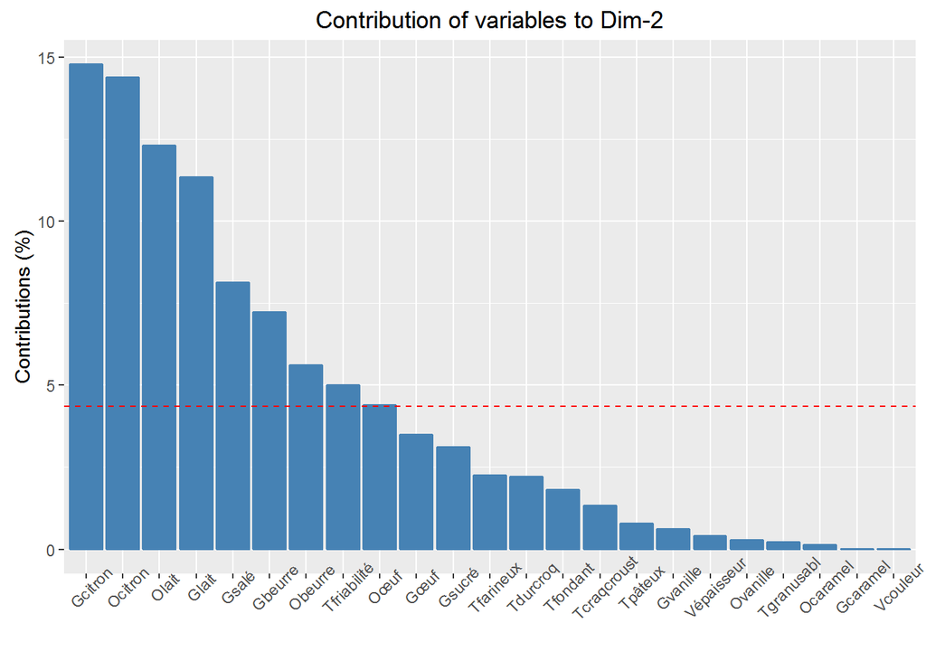

```r
fviz_contrib(res.pca, choice = "var", axes = 2)
```

```r
library(plotly)
bubble1=gvisBubbleChart(data,idvar ='juge',xvar = 'Gcitron',yvar = 'Vcouleur',colorvar='produit',sizevar='seance',options=list(hAxis='{minvalue:1,maxvalue:10}',width=1000,height=1000))
plot(bubble1)
```

[Bubble1] (http://127.0.0.1:26473/custom/googleVis/BubbleChartID18304969670f.html)

### IV Cartographie

```r
Tableau_cons<-read.table(file=file.choose(),header=T, sep=";")
Tableau_cart=cbind.data.frame(Tableau_cons,Tableau_moyen_originaire,row.names=1)
rownames(Tableau_cart)<-Tableau_cons[,1]
dim(Tableau_cart)
```

```
## [1]   8 318
```

```r
dim(Tableau_moyen)
```

```
## [1]  8 24
```

```r
Tableau_cart[,318]
```

```
## [1] France   France   France   France   Pakistan Pakistan Pakistan Pakistan
## Levels: France Pakistan
```

```r
Tableau_cart[,295]
```

```
## [1] 6.083333 9.125000 3.000000 7.416667 3.541667 4.500000 5.916667 6.666667
```

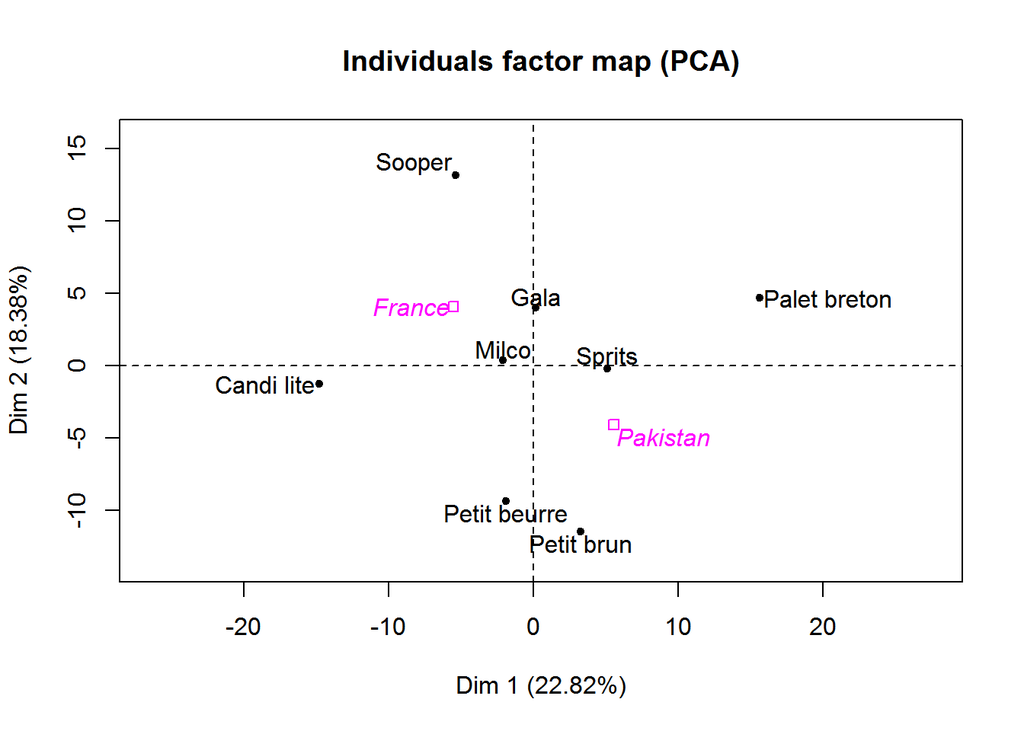

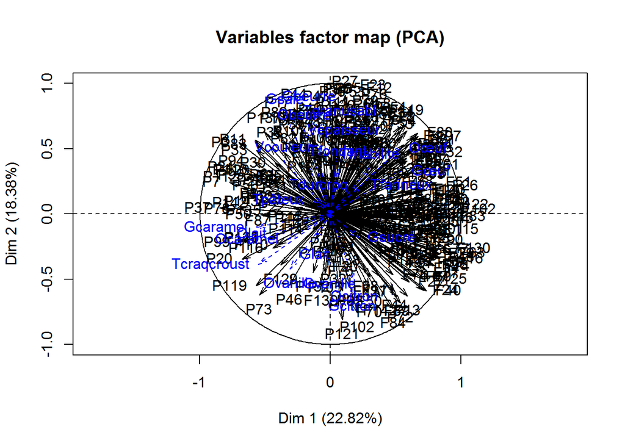

```r
library(FactoMineR)
res.pca<-PCA(Tableau_cart, quanti.sup = 295:317,quali.sup = 318)
```

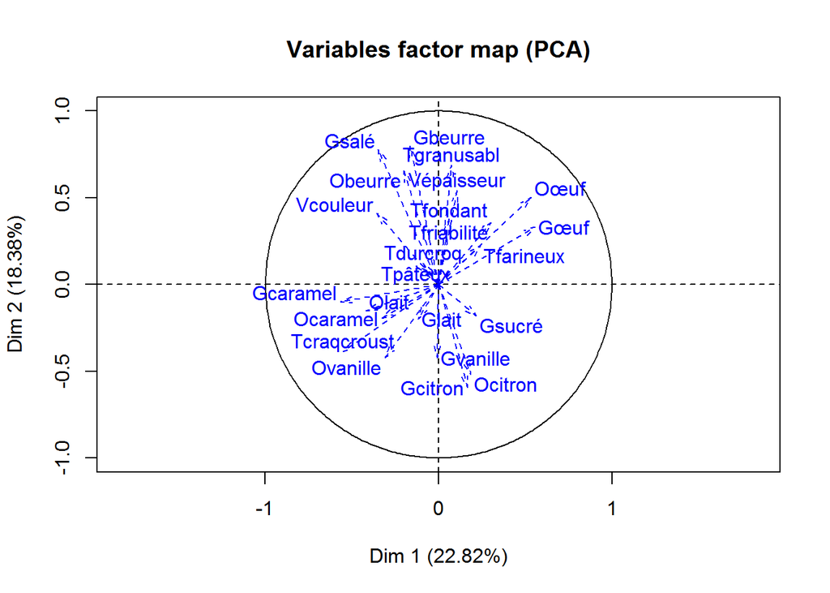

```r
plotP<-plot.PCA(res.pca, choix = "var", invisible = "var")
```

```r
library(gridExtra)
```

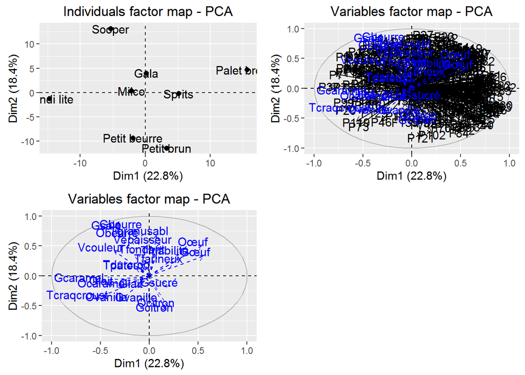

```r
library(devtools)
p1<-fviz_pca_var(res.pca, invisible = "var")
p2<-fviz_pca_ind(res.pca)
p3<-fviz_pca_var(res.pca)
grid.arrange(p2, p3, p1, nrow=2, ncol = 2)
```